# IODS course project

Although there really is no beating the visual ease of the comparison of the sample quantiles to a staight line drawn on the basis of the theoretical quantiles provided by the Q-Q -plot, let us see what an estimated density plot of the residuals would look like.

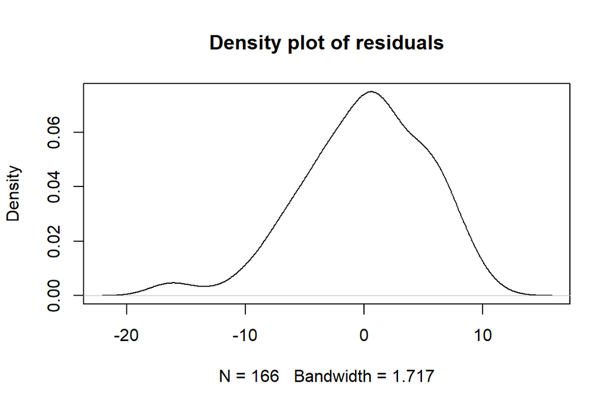

```r
# draw diagnostic plots using the plot() function. Choose the plots 1, 2 and 5
plot(density(resid(my_model2)),main="Density plot of residuals")
```

Here we see that our kernel estimate provides a density that appears as normal as one ever tends to get with actual data. However, we do observe the impact of the outliers, as those observed values that are much lower than expected in terms of our model fit produce a left tail that is fatter than the normal distribution allows for.

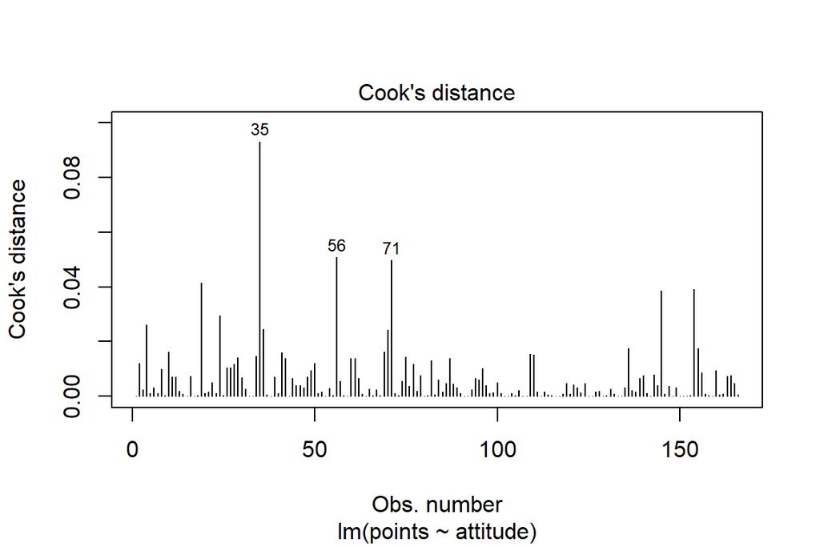

```r
# draw diagnostic plots using the plot() function. Choose the plots 1, 2 and 5
plot(my_model2,which=4)
```

Indeed, none of the observations have a Cook’s distance anywhere near 1, so there is no need to be concerned about influential observations with unduly strong effects on our regression estimates.

We conclude that our model provides an adequate fit to the data and none of the assumptions inherent in our simple linear regression model whose parameters are estimated on the basis of ordinary least squares are seriously violated.

We conclude that attitude towards statistics seems to be an important predictor of exam performance and warrants a more detailed analysis in future quantitative research. Such analysis could, for instance, provide a better understanding of whether we could put these initial findings of ours to practical use in, for example, enhancing learning of statistics by improving the attitudes students have towards it.

# A case study in logistic regression and cross-validation

*In the following, we will see whether or not we can predict alcohol consumption* *of pupils in secondary school in Portugal by a set of predictors on their background and* *their school performance. We will categorize our outcome variable into two classes: high* *consumption, and its complement class. We will fit a logistic regression model for our* *classification task. We will also take a brief look at the topic of cross-validation.*

In the following, we work with a dataset that is openly available from the UC Irvine Machine Learning Repository. It is a dataset comprising of two original tables measuring secondary school pupils’ background, study performance and other variables of interest for educational sciences and policy. We have preprocessed the data so that we have joined the two tables together for all those pupils we have identified as having answered both the two questionnaires that formed the originally distinct datasets. For those questions that these pupils have provided discordant answers to in the two datasets, we have either used an average value over the two datasets, if the items are numeric, or else just taken the first value of the two provided answers.

```
## [1] "Mon Dec 11 16:32:04 2023"
```

We first read in the analysis dataset in which we have joined the two original datasets. We also take a glimpse at the dataset.

```r
# We require the library readr for reading in our dataset
library(readr)

# Read the file into the workspace
alc<-read_csv("~/Intro_to_ODS/IODS/data/alc.csv")
# We print the names of the variables in the dataset
colnames(alc)
```

```
##  [1] "school"     "sex"        "age"        "address"    "famsize"
##  [6] "Pstatus"    "Medu"       "Fedu"       "Mjob"       "Fjob"
## [11] "reason"     "guardian"   "traveltime" "studytime"  "schoolsup"
## [16] "famsup"     "activities" "nursery"    "higher"     "internet"
## [21] "romantic"   "famrel"     "freetime"   "goout"      "Dalc"
## [26] "Walc"       "health"     "failures"   "paid"       "absences"
## [31] "G1"         "G2"         "G3"         "alc_use"    "high_use"
```

```r
# We require dplyr for glimpse
library(dplyr)
# We provide a glimpse of the dataset
glimpse(alc)
```

```
## Rows: 370
## Columns: 35
## $ school     <chr> "GP", "GP", "GP", "GP", "GP", "GP", "GP", "GP", "GP", "GP",~
## $ sex        <chr> "F", "F", "F", "F", "F", "M", "M", "F", "M", "M", "F", "F",~
## $ age        <dbl> 18, 17, 15, 15, 16, 16, 16, 17, 15, 15, 15, 15, 15, 15, 15,~
## $ address    <chr> "U", "U", "U", "U", "U", "U", "U", "U", "U", "U", "U", "U",~
## $ famsize    <chr> "GT3", "GT3", "LE3", "GT3", "GT3", "LE3", "LE3", "GT3", "LE~
## $ Pstatus    <chr> "A", "T", "T", "T", "T", "T", "T", "A", "A", "T", "T", "T",~
## $ Medu       <dbl> 4, 1, 1, 4, 3, 4, 2, 4, 3, 3, 4, 2, 4, 4, 2, 4, 4, 3, 3, 4,~
## $ Fedu       <dbl> 4, 1, 1, 2, 3, 3, 2, 4, 2, 4, 4, 1, 4, 3, 2, 4, 4, 3, 2, 3,~
## $ Mjob       <chr> "at_home", "at_home", "at_home", "health", "other", "servic~
## $ Fjob       <chr> "teacher", "other", "other", "services", "other", "other", ~
## $ reason     <chr> "course", "course", "other", "home", "home", "reputation", ~
## $ guardian   <chr> "mother", "father", "mother", "mother", "father", "mother",~
## $ traveltime <dbl> 2, 1, 1, 1, 1, 1, 1, 2, 1, 1, 1, 3, 1, 2, 1, 1, 1, 3, 1, 1,~
```

[output cut: 22 more lines]

We may note that the dataset is rather rich: it contains 35 variables, many of which might be predictive of alcohol consumption. The names of the variables provide good indication on the type of data on the secondary shool pupil we have at our disposal: the school the pupil attends, the gender, the age, family size, whether parents live together, mother’s education, father’s education, mother’s job, father’s job, reason to choose the school one attends, who is the pupil’s guardian etc. Most of the variables can be characterized as sort of ‘’background variables’’: they are, for the most part, not potential outcomes of interest for the educational scientist. Perhaps the most notable exceptions are the variables having to do with educational attainment: failed courses, absences, and the grades from the first and second period as well as the final grade (G1, G2, G3, respectively: in joining the datasets we have averaged the grades from the portuguese and the math classes).

One might, however, also be interested in understanding, explaining and predicting the phenomenon of alcohol consumption. Instead the outcomes on educational attainment, that is what we are to delve into in the next.

We have an abundance of variables that might be of interest in understanding or predicting the phenomenon of alcohol consumption among secondary school pupils. We could proceed in a data-driven fashion and aim to identify predictors with most predictive potential by exploratory data analysis. Instead, we start from a more “theory-laden” perspective, identifying variables that would seem likely to be associated with our outcome of interest prior to taking any closer look at the data. Even though we are no genuine substance-matter experts here, we may nonetheless have some valuable life experience of our own that may help inform us where to look when trying to understand or predict alcohol consumption of an adolescent.

We thus hypothesize that men consume more than women, and choose gender as one of our predictors of interest. We further hypothesize that those whose parents have split up tend to drink more. Socioeconomic status is likely to have an effect as well, so that we might we well-advised to construct a composite indicator based on the likes of parents’ education and work status. However, we hypothesize that much of the predictive power that the socioeconomic status might have, is captured by the dichotomy of whether or not the pupil plans to attend higher education, so we choose that as our second predictor of interest with the associated hypothesis that those planning not to attend higher education consume more alcohol. We further postulate that alcohol consumption, for adolescents, is a form of social activity, so we choose ‘’going out with friends’’ as our third potential predictor of interest. This is a variable measured on an ordinal scale, with 1=“very low” and 5=“very high”, supposedly meaning that a value of 5 means one goes out with friends a lot. We might come to treat the predictor, however, as if it were interval-scaled, and postulate that higher values are associated with increased alcohol consumption. We further postulate that absences from school and the quality of family relationships might be associated with alcohol consumption. We choose the latter for our model, if only because it involves less preprocessing: absences being an integer-valued variable with a range from 0 to 93, one might be well-advised to look more closely into the classes of levels of absence that matter for prediction. Family relationships is an ordinal variable ranging from 1=“very bad” to 5=“excellent”, yet we might come to treat it as if it were interval-valued, and hypothesize that better family relations are associated with lower alcohol consumption.

Final note before proceeding. We could approach logistic regression modelling with high alcohol consumption as the outcome of interest from roughly two perspectives: understanding some relationship an area of life or a background of the adolescent has with that of his alcohol use; or, aiming to most adequately explain or predict that alcohol use. In the former case, we could restrict attention to, say, one perpective, such as “family background”. We could then choose predictors that fall exclusively within that class. On the latter perspective, instead, we would be well-advised to proceed by first identifying those dimensions of the life and background of the secondary school pupil most closely related with alcohol consumption, then choose a single (perhaps a composite such) predictor from each such distinct dimension, and use those as the predictors in one’s model. In so doing, we would be following a heuristic for maximizing predictive performance given that we are to include but a fixed amount of predictors (four, in our case): summarizing the correlated predictors in a single predictor, and picking all those distinct sets of such predictors that might independently explain or predict our outcome of interest.

We have, strictly speaking, not followed either of these strategies in their pure forms, although our approach leans more on the ‘’predictive’’ than the ‘’understanding’’ function. We also note that we have painted a rather dim perspective on alcohol consumption, and that we risk missing some of the phenomenon in treating it so heavily as indicating other problems that the pupil might have.

We start by producing some simple summaries of the dataset in line with our dichotomous outcome of interest and our four predictors, two of which are binary and two of which are integer-valued.

We first look at each predictor separately with the outcome.

We start by looking at hich alcohol consumption by sex.

```r
# Produce proportions of high-alcohol use by sex
table(high_use=alc$high_use, sex=alc$sex) %>% prop.table() %>% addmargins()
```

```
##         sex
## high_use         F         M       Sum
##    FALSE 0.4162162 0.2837838 0.7000000
##    TRUE  0.1108108 0.1891892 0.3000000
##    Sum   0.5270270 0.4729730 1.0000000
```

The proportions provided in the table indicate that sex is associated with high alcohol consumption, and it is indeed so in the way that we hypothesized: men have a higher proportion of ‘’heavy drinkers’’ than do women (note that this is based on their self-reported values). 40% of men pupils in the dataset fall within this category, while only roughly 20% of the women do.

We have the following bar-plot to visualize the above and provide the counts.

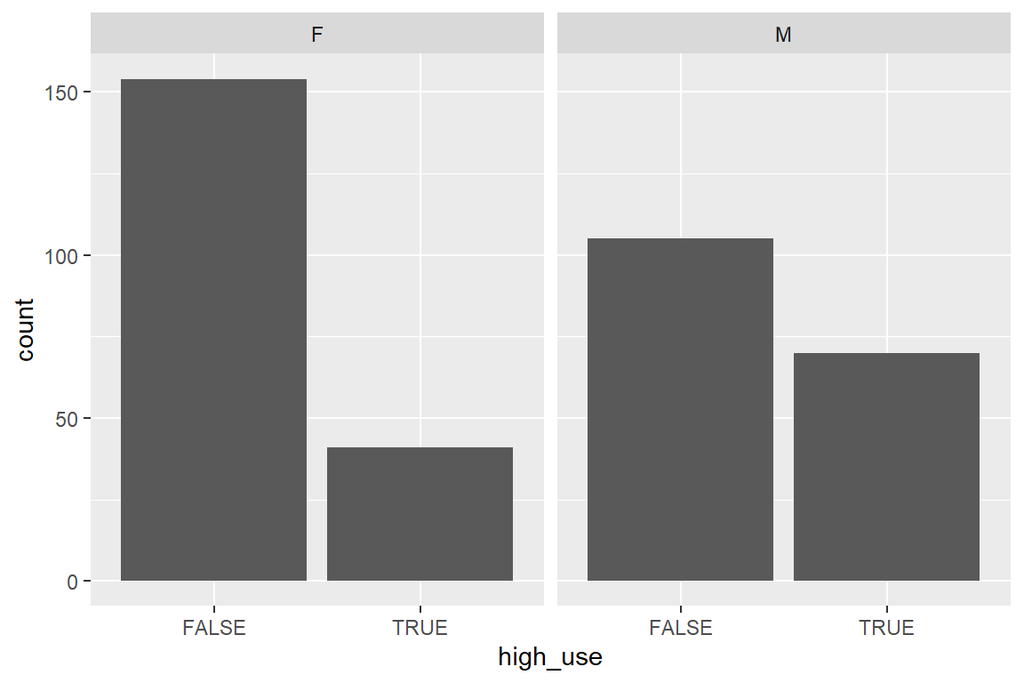

```r
# We require the library ggplot2 for visuals
library(ggplot2)

# Initialize a plot of 'high_use'
g <- ggplot(data = alc, aes(x=high_use))

# draw a bar plot of high_use by sex
g<-g + geom_bar()

# add the sex
g + facet_wrap("sex")
```

We reproduce the above for the case of planning to attend higher education.

```r
# Produce proportions of high-alcohol use by planning to attend higher education

table(high_use=alc$high_use, higher_educ=alc$higher) %>% prop.table() %>% addmargins()
```

```
##         higher_educ
## high_use         no        yes        Sum
##    FALSE 0.01891892 0.68108108 0.70000000
##    TRUE  0.02432432 0.27567568 0.30000000
##    Sum   0.04324324 0.95675676 1.00000000
```

While out of those that do not plan to attend higher education in our sample, roughly 55% have a high-consumption of alcohol, this predictor is unfortunately likely not to be of much use in our classification task, since it is what one might call a ‘’near zero variance’’ predictor, since, surprisingly (is the school some elite school, perhaps?), almost all pupils plan to attend higher education. The inclusion of this predictor in our model might even turn out detrimental, since it might result in a failure of convergence for our maximum-likelihood regression coefficient estimates – a case which is quite common in logistic regression.

In terms of our prior hypothesis, the observed association in our sample is in the direction we hypothesized: if one is not planning to attend higher education, one is more likely to fall in the class of ‘’high alcohol consumption’’. However, the partition of our dataset that is not planning to attend higher education is so small, that one cannot make much of the hypothesized association.

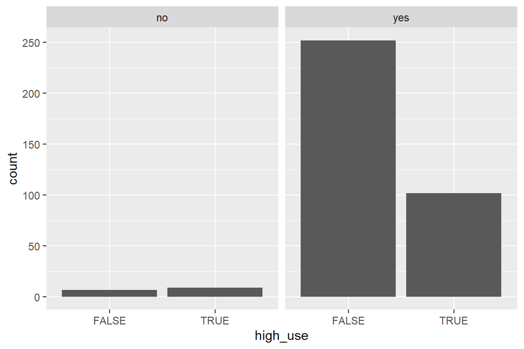

```r
# We require the library ggplot2 for visuals
library(ggplot2)

# Initialize a plot of 'high_use'
g <- ggplot(data = alc, aes(x=high_use))

# draw a bar plot of high_use by plan to attend higher education
g<-g + geom_bar()

# add the higher education plan dichotomy
g + facet_wrap("higher")
```

We next take a look at the association of ‘’going out with friends’’ with that of high alcohol consumption.

First, a simple table of the counts and the means.

```r
# Produce summary statistics by group

alc %>% group_by(high_use) %>% summarise(count=n(),mean_goout=mean(goout))
```

```
## # A tibble: 2 x 3
##   high_use count mean_goout
##   <lgl>    <int>      <dbl>
## 1 FALSE      259       2.85
## 2 TRUE       111       3.73
```

We see that the sample mean for ‘’going out with friends’’ is clearly higher in the category of those with high alcohol consumption, as we hypothesized it would be. The mean does not tell much of the overall distribution, so let us take a look at a visual that can do that.

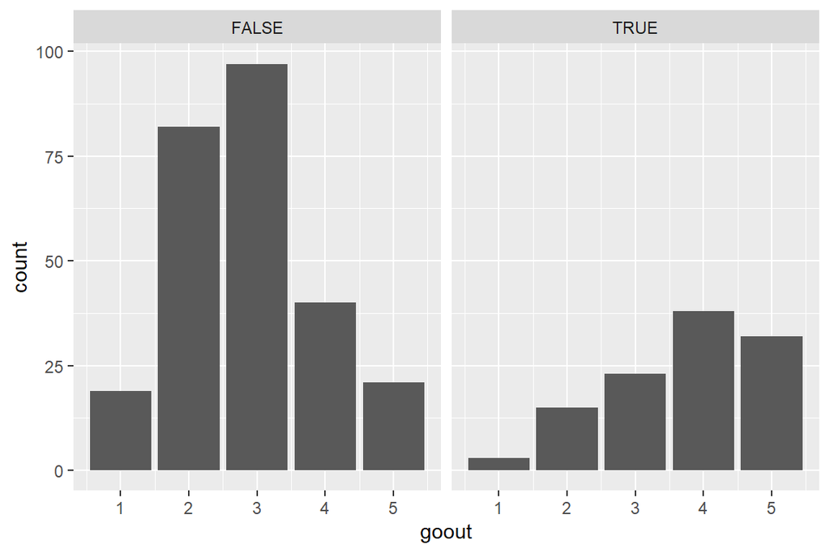

```r
# We require library ggplot2 for the visuals
library(ggplot2)

# Initialize a plot of 'high_use'
g <- ggplot(data = alc, aes(x=goout))

# Draw a bar plot of high_use by plan to attend higher education
g<-g + geom_bar()

# add the higher education plan dichotomy
g + facet_wrap("high_use")
```

We may observe that the bar-plots have opposite ‘’skews’‘: those that fall within the’‘high consumption’’ group have more of the high values of ‘’going out with friends’‘; while those in the’‘not-high consumption’’ group have more of the low values.

So our data is aligned with our hypothesis, yet again. We also observe, however, that we ought perhaps not treat our integer-valued and ordinal ‘’going out with friends’’ -predictor as if it were interval-valued in our model, since a unit increase in our predictor does not seem to have a consistent multiplicative effect on the odds of our outcome event of interest.

We print the table for the counts to back up our visual and the conclusions from it.

```r
# Produce proportions of high-alcohol use by planning to attend higher education

table(high_use=alc$high_use, goout=alc$goout) %>% addmargins()
```

```
##         goout
## high_use   1   2   3   4   5 Sum
##    FALSE  19  82  97  40  21 259
##    TRUE    3  15  23  38  32 111
##    Sum    22  97 120  78  53 370
```

We could pretty much lump the predictor categories 1,2 and 3 into a single category, and keep the 4 and 5 as the other two in our newly introduced trichotomy. This would reduce some of the information we have, though, since the categories 1,2 and 3 are not strictly speaking on par. It is best to treat the predictor as a factor, so we add it to our data and use it as a factor instead as numeric in our model.

```r
# Add goout as factor
alc <- mutate(alc, goout_fac=as.factor(goout))
```

Finally, we take a look at our ‘’family relations’’ variable and its relation with our dichotomous outcome of interest.

```r
# Produce summary statistics by alcohol consumption dichotomy

alc %>% group_by(high_use) %>% summarise(count=n(),mean_famrel=mean(famrel))
```

```
## # A tibble: 2 x 3
##   high_use count mean_famrel
##   <lgl>    <int>       <dbl>
## 1 FALSE      259        4.01
## 2 TRUE       111        3.77
```

We observe that the mean of our ‘’family relations’’ variable is lower for those falling in the ‘’high alcohol consumption’’ group, as we hypothesized. Let’s take a look at the bar plot to display the distribution partitioned by our alcohol consumption dichotomy.

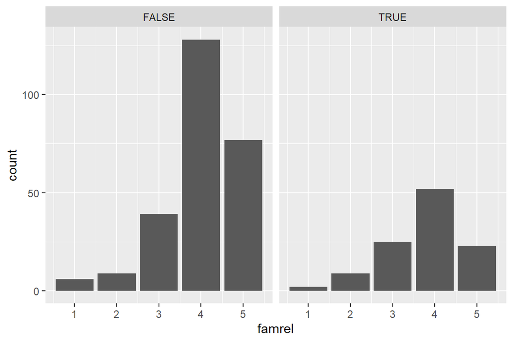

```r
# We require library ggplot2 for the visuals
library(ggplot2)

# Initialize a plot of 'high_use'
g <- ggplot(data = alc, aes(x=famrel))

# Draw a bar plot of high_use by plan to attend higher education
g<-g + geom_bar()

# add the higher education plan dichotomy
g + facet_wrap("high_use")
```

These look quite similar in terms of their shape, if not the absolute counts.

```r
# Produce proportions of high-alcohol use by planning to attend higher education

table(high_use=alc$high_use, famrel=alc$famrel) %>% addmargins()
```

```
##         famrel
## high_use   1   2   3   4   5 Sum
##    FALSE   6   9  39 128  77 259
##    TRUE    2   9  25  52  23 111
##    Sum     8  18  64 180 100 370
```

We may observe that our class with a value of 1 for family relations is very small, so we decide to combine it with the class that have a value of 2. We further turn the variable into a factor, as we did in the previous, for similar reasons as in the previous.

Note that we have not turned the factor into an *ordered* factor. So our logistic regression will not treat it as if it were ordinal, but as if it were categorical. By so doing, we fail to account for some of the inherent structure in our dataset. Yet we allow each coefficient of a factor level to be interpreted relative to the baseline level of that factor.

```r
# Recode famrel so that we combine values 1 and 2 into a value of 1
alc<- mutate(alc, famrel=recode(famrel, '1'=1, '2'=1, '3'=2, '4'=3,'5'=4))
alc<- mutate(alc, famrel_fac=as.factor(famrel))
```

We note that it would usually be good to explore the multidimensional relationships between the predictors and the outcome variable prior to regression modeling. However, since we treat none of our predictors as numeric, our multidimensional visuals tend to become disorderly. Thus we settle for these and proceed to modeling.

Logistic regression is a generalized linear model that uses the logit as its link function.

This means that we would have the following form for our logistic regression model with four predictor variables:

$\log({\frac{p}{1-p}})=b_0 + b_1x_1 + b_2x_2 + b_3x_3 + b_4x_4$,

*if we did not utilize factor variables*, as we of course exclusively do. In our case, each level of a factor, except the baseline level of the factor, is equipped with its own regression coefficient. The logit link function is handy in terms of the intuitive interpretation it offers for the exponential of the regression coefficient estimate as the *odds ratio*. This means that, a unit increase in the predictor variable, say $x_1$, is associated with $b_1$-fold increase in the odds, $\frac{p}{1-p}$, of the event. In our case the event of interest is ‘’high alcohol consumption’‘, and each $\exp(b)$, is comparative with respect to the baseline level of its factor. R in essence dummy-codes our factor levels for us so that’‘a unit increase’’ amounts simply to a shift from the baseline level of the factor to the level of the predictor that our regression coefficient denotes. So if, say, $\exp(b_4)=2$, then the odds of ‘’high alcohol consumption’’ are two-fold for $x_4$ relative to its baseline level.

```r
# find the model with glm()
m <- glm(high_use ~ famrel_fac + goout_fac + higher + sex, data = alc, family = "binomial")

summary(m)
```

```
##
## Call:
## glm(formula = high_use ~ famrel_fac + goout_fac + higher + sex,
##     family = "binomial", data = alc)
##
## Deviance Residuals:
##     Min       1Q   Median       3Q      Max
## -1.6032  -0.7657  -0.4871   0.8374   2.4355
##
## Coefficients:
##             Estimate Std. Error z value Pr(>|z|)
## (Intercept)  -1.4079     0.9512  -1.480 0.138816
## famrel_fac2   0.1560     0.5486   0.284 0.776196
## famrel_fac3  -0.6005     0.4997  -1.202 0.229496
## famrel_fac4  -1.1184     0.5374  -2.081 0.037421 *
## goout_fac2    0.1217     0.6960   0.175 0.861195
## goout_fac3    0.4448     0.6774   0.657 0.511360
## goout_fac4    1.9576     0.6760   2.896 0.003781 **
## goout_fac5    2.3721     0.7000   3.389 0.000702 ***
## higheryes    -0.5082     0.5993  -0.848 0.396415
## sexM          1.0122     0.2650   3.820 0.000134 ***
## ---
## Signif. codes:  0 '***' 0.001 '**' 0.01 '*' 0.05 '.' 0.1 ' ' 1
##
## (Dispersion parameter for binomial family taken to be 1)
##
##     Null deviance: 452.04  on 369  degrees of freedom
## Residual deviance: 369.89  on 360  degrees of freedom
## AIC: 389.89
##
## Number of Fisher Scoring iterations: 4
```

We note that we have the correct amount of regression coefficient estimates, one less for each factor variable than the amount of the levels it has. The baseline for ‘’family relations’’ is the level ‘’1’‘, which denotes’‘very bad’’ or ‘’bad’’ family relations. The baseline for ‘’going out with friends’’ is also ‘’1’‘, which denotes a’‘very low’’ value. The baseline for planning to go attend higher education is not planning to attend, and the baseline for male sex is female sex. We note that only a few of the levels have a statistically significant regression coefficient estimate associated with them. These are ‘’family relations’’ with value ‘’excellent’‘; going out with values’‘high’’ and ‘’very high’’, as well as the male sex. For all of these, the order is as had been hypothesized: the first in the list decreasing the odds of high consumption, the following three increasing it, *when holding all of the other predictors in the model constant*.

But before interpreting the regression coefficient estimates, we should exponentiate these, so that we may utilize the ease of the odds-ratio interpretation. We also derive the 95% confidence intervals for the exponentials of the coefficient estimates (the odds ratios attached to each predictor).

```r
# find the model with glm()
m <- glm(high_use ~ famrel_fac + goout_fac + higher + sex, data = alc, family = "binomial")

# compute odds ratios (OR)
OR <- coef(m) %>% exp

# compute confidence intervals (CI)
CI <- confint(m) %>% exp
# print out the odds ratios with their confidence intervals
cbind(OR, CI)
```

```
##                     OR      2.5 %     97.5 %
## (Intercept)  0.2446487 0.03352111  1.4692192
## famrel_fac2  1.1687773 0.40156995  3.4931207
## famrel_fac3  0.5485248 0.20690197  1.4884929
## famrel_fac4  0.3268105 0.11343518  0.9447502
## goout_fac2   1.1294034 0.31969632  5.3336017
## goout_fac3   1.5602481 0.46358899  7.1849404
## goout_fac4   7.0825545 2.12129236 32.6071661
## goout_fac5  10.7203751 3.04383540 51.1754486
## higheryes    0.6015482 0.18026784  1.9500032
## sexM         2.7515313 1.64749202  4.6669774
```

So an OR of 1 means that the odds are pretty much on par relative to the comparator of the baseline level. We notice that, as of course roughly should be, the predictors we found to be statistically significant with a two-sided test of the null of ‘’nil association’’ (here OR of 1) in the above, are the ones the confidence interval of which does not contain the value 1. For ‘’famrel_fac4’’ the upper bound is below 1 (indicating a decrease in odds comparative to the baseline); for ‘’goout_fac4’’ and ‘’goout_fac5’’ the lower bounds are above 1 (indicating an increase in odds comparative to the baseline); as it is for the male sex (indicating an increase in odds of the event in comparison to the baseline provided by the female sex).

We infer that our best point estimate is that ‘’excellent’’ family relations decrease the odds of high alcohol consumption by a multiplicative factor of 0.3. in comparison to the baseline of ‘’bad’’ or ‘’very bad’’ relations (when other predictors in the model our held constant). Our associated interval estimate with a 95% confidence level is from roughly a 0.1 to a 0.9 -fold decrease in odds.

Our best estimate for a ‘’high’’ value provided for ‘’going out with friends’’ is that this is associated with roughly a 7-fold increase in odds in comparison to the baseline of a ‘’very low’’ value (when other predictors in the model our held constant), and that we are 95% confident that the odds ratio is between roughly 2 and 32. For a value of ‘’very high’’, we have similar numbers of 10, 3, and 51, respectively.

Being male is associated with roughly a 2.7-fold increase in the odds of high alcohol consumption in comparison to women (when other predictors in the model our held constant). We are 95% confident that the male sex is associated with a 1.6 to 4.7-fold increase in the odds of high alcohol consumption.

Our point estimate for the OR of planning to attend higher education suggests that the odds of high alcohol consumption are decreased 0.6-fold in comparison to the baseline of planning not to attend. However, with the small number of observations in the reference group, we have a wide confidence interval, and cannot reject the null of an OR of 1, as its truve value might very well be as high as roughly 2. However, we note that this issue deserves further study, since the point estimate is suggestive of a substantive association.

We will end by making predictions based on our model. We include all our predictor variables in the model, even though planning to attend higher education fails to have a statistically significant regression coefficient estimate, since it nonetheless is likely to increase our predictive power (even if only a little). We will also plot the confusion matrix to assess performance.

```r
# Fit the model
m <- glm(high_use ~ famrel_fac + goout_fac + higher + sex, data = alc, family = "binomial")

# Predict() the probability of high_use
probabilities <- predict(m, type = "response")

library(dplyr)
# add the predicted probabilities to 'alc'
alc <- mutate(alc, probability = probabilities)

# use the probabilities to make a prediction of high_use
alc <- mutate(alc, prediction = probability > 0.5)

# see the last ten original classes, predicted probabilities, and class predictions
select(alc, failures, absences, sex, high_use, probability, prediction) %>% tail(10)
```

```
## # A tibble: 10 x 6
##    failures absences sex   high_use probability prediction
##       <dbl>    <dbl> <chr> <lgl>          <dbl> <lgl>
##  1        0        3 M     FALSE         0.257  FALSE
##  2        1        0 M     FALSE         0.201  FALSE
##  3        1        7 M     TRUE          0.171  FALSE
##  4        0        1 F     FALSE         0.0698 FALSE
##  5        0        6 F     FALSE         0.112  FALSE
##  6        1        2 F     FALSE         0.0515 FALSE
##  7        0        2 F     FALSE         0.364  FALSE
##  8        0        3 F     FALSE         0.128  FALSE
##  9        0        4 M     TRUE          0.813  TRUE
## 10        0        2 M     TRUE          0.182  FALSE
```

```r
# tabulate the target variable versus the predictions
table(high_use = alc$high_use, prediction = alc$prediction)
```

```
##         prediction
## high_use FALSE TRUE
##    FALSE   240   19
##    TRUE     57   54
```

We can see from the confusion matrix that we are able to predict the non-cases (not-high alcohol consumption) rather well, which is not surprising, given the we have an initial setting of a class imbalance, with 70% of the observations non-cases. Out of these, we are able to predict $\frac{240}{259}\sim 0.92$ (this is the specificity of our classifier). Of the cases, though, we are able to predict only but roughly half (this is the sensitivity of our classifier). Overall, our prediction accuracy, i.e. the proportion of correct predictions is: $\frac{240+54}{370}\sim 0.795$. A baseline model with no predictors would be able to achieve accuracy of $0.7$ by guessing all observations to be ‘’non-cases’’ (not-high alcohol consumption). A simple statistical test can be used to assess whether our model is significantly better in comparison to this null model, but it is clear that it is even without the test. More important is whether our model is good enough to be useful, and this depends on the use to which our model is to be put. One could already claim that, in general, the increase in accuracy achieved by our model in comparison to the baseline is modest, but could still prove useful.

Our model has been fitted and assessed on the entire dataset in the above. This means that we have likely overfitted the model, and its performance on a test dataset that the model has not been trained on would be lower than what we observed on the training dataset alone. To guard one from overfitting, one should use cross-validation techniques. Here, one would be well advised to first split the data into a training and a test dataset (the latter could comprise of, say, 20% of the observations). Then, one would conduct cross-validation on the training dataset, for instance, by leaving aside some proportion of the training set for validation on each iteration on which one trains the model by tuning its parameters to optimize performance on a chosen criterion. One would loop through such iterations, by taking a different partitioning into training and validation on each iteration. In each of these iterations, the model would be assessed in the validation dataset, its performance stored, and at the end of all of the iterations, a summary of the performance (usually just the mean performance) across the iterations would be provided. One would then choose the best model on the basis of this aggregare performance measure, and, finally, evaluate that model against the test (‘’holdout’’) dataset which we had initially set aside to ensure that performance be assessed truthfully on a dataset the model had not seen in its training phase.

Now in such a development one would have a collection of classifiers and, of course, simple logistic regression would tend not to prevail as the best performing method (although, its extention to an elastic net penalty found in the glmnet package is already often rather good). Furthermore, accuracy is rarely a good performance criterion to use when training the model, especially in the case of a class imbalanced classifier, since we should usually like our model to be able to detect the cases. In general, this is just to say that the loss function should not be 0-1 off-the-shelf, so that one accrues a penalty of 1 for each ‘’miss’’ regardless of its type (and zero for a correct prediction). One ought instead construct a loss function that accounts for the context of the use of the model, and in such context, it is invariably the case that some types of errors are more costly than others (such as the false negatives in comparison to the false positives – just think of a case where our classifier is a diagnostic device aiming to detect the presense of a disease). Since one always trades off sensitivivity with specificity, a good standard performance measure for a classifier is often the area under the ROC-curve (AUC). After having trained and optimized the classifier in terms of AUC, one may then proceed to choose an appropriate detection level (a probability threshold) for classifying a case as such. This threshold could then be chosen so as to account for the losses attached to the different types of errors in the use context.

We may encode our 0-1 loss for the predictions (penalizing 0 in the case of a correct prediction and 1 in case of an incorrect one) as below and observe that our loss is the proportion of incorrect predictions: a value which is the negation of the accuracy of our model we calculated in the above.

```r
# Define a loss function (mean prediction error)
loss_func <- function(class, prob) {
  n_wrong <- abs(class - prob) > 0.5
  mean(n_wrong)
}

# call loss_func to compute the average number of wrong predictions in the (training) data


# This is the proportion of wrong predictions
loss_func(class = alc$high_use, prob = alc$probability)
```

```
## [1] 0.2054054
```

We may conduct 10-fold cross validation (where on each iteration a different 10% of the training data is used for validation) of our model and assess overall performance with the following code, utilizing the boot-library.

```r
# define a loss function (average prediction error)
loss_func <- function(class, prob) {
  n_wrong <- abs(class - prob) > 0.5
  mean(n_wrong)
}

# compute the average number of wrong predictions in the (training) data


# K-fold cross-validation
library(boot)
cv <- cv.glm(data = alc, cost = loss_func, glmfit = m, K = 10)

# average number of wrong predictions in the cross validation
cv$delta[1]
```

```
## [1] 0.2189189
```

We conlude that our model is decent at best, when evaluated with a loss-function (and a performance criterion) that is usually not the go-to choice. Our model outperforms a null model guessing a non-case each time (which would have accuracy of 0.7).

Note that we would still want to assess the performance of our classifier on a further never-seen-before dataset prior to concluding on final performance.

# A case study in linear discriminant analysis and K-means clustering

*In the following, we will use linear discriminant analysis and K-means clustering for grouping our data on housing in the Boston area. The dataset we utilize is openly available from the MASS-package in R.*

We have a somewhat similar task at our hands as with logistic regression: our purpose is to be able to sort our dataset into distinct classes. One way to do this is to predetermine the class labels, and then utilize the features in the dataset to predict those labels. This classification task is then a form of *supervised learning*, one example of which we already introduced in the above with logistic regression. Another alternative for completing a similar task is that of linear discriminant analysis, a limitation of which is that the predictors ought to be normally distributed (which also implies they must be continuous, of course).

Another approach to grouping data items is that inherent in *unsupervised learning*, where the correct class labels are not provided in the training dataset, but are instead determined by the algorithm itself, usually based on some distance measure between the groups induced. A classical example is that of K-means clustering where one must provide the number of groups for the algorithms, even if not their labels. We will look into both approaches in what follows.

```
## [1] "Mon Dec 11 16:32:05 2023"
```

## Load and describe the dataset

We read in the openly available dataset ‘’Boston’’ from the MASS-package and take our first look at it.

```r
# We require the MASS package for our dataset
library(MASS)
# load the data
data("Boston")

# explore the dataset
str(Boston)
```

```
## 'data.frame':    506 obs. of  14 variables:
##  $ crim   : num  0.00632 0.02731 0.02729 0.03237 0.06905 ...
##  $ zn     : num  18 0 0 0 0 0 12.5 12.5 12.5 12.5 ...
##  $ indus  : num  2.31 7.07 7.07 2.18 2.18 2.18 7.87 7.87 7.87 7.87 ...
##  $ chas   : int  0 0 0 0 0 0 0 0 0 0 ...
##  $ nox    : num  0.538 0.469 0.469 0.458 0.458 0.458 0.524 0.524 0.524 0.524 ...
##  $ rm     : num  6.58 6.42 7.18 7 7.15 ...
##  $ age    : num  65.2 78.9 61.1 45.8 54.2 58.7 66.6 96.1 100 85.9 ...
##  $ dis    : num  4.09 4.97 4.97 6.06 6.06 ...
##  $ rad    : int  1 2 2 3 3 3 5 5 5 5 ...
##  $ tax    : num  296 242 242 222 222 222 311 311 311 311 ...
##  $ ptratio: num  15.3 17.8 17.8 18.7 18.7 18.7 15.2 15.2 15.2 15.2 ...
##  $ black  : num  397 397 393 395 397 ...
##  $ lstat  : num  4.98 9.14 4.03 2.94 5.33 ...
##  $ medv   : num  24 21.6 34.7 33.4 36.2 28.7 22.9 27.1 16.5 18.9 ...
```

We have a dataset with 506 observations on 14 variables. We have 12 numeric variables and 2 integer-valued variables. Apparently the statistical units here are suburbs or towns within the Boston area. This dataset has no missing values.

```r
sum(is.na(Boston))
```

```
## [1] 0
```

‘’Crim’’ is a variable on the crime rate per capita; ‘’zn’’ is proportion of residential land zoned; ‘’indus’’ is proportion of non-retail business acres per town; ‘’chas’’ is an indicator for the suburb being adjacent to Charles river; ‘’nox’’ is nitrix oxides concentration in air; ‘’rm’’ is average rooms per apartment; ‘’age’’ is proportion of owner-occupied units built prior to 1940; ‘’dis’’ is a distance measure to five Boston employment centres; ‘’rad’’ measures highway accessibility; ‘’tax’’ measures property tax rate; ‘’ptratio’’ is the pupil-teacher ratio; ‘’black’’ measures the proportion of african-americans, ‘’lstat’’ proportion that is lower status of the population (whatever that might mean!) and ‘’medv’’ median value of homes in thousands of dollars.

The variables measure a wide range of interesting characteristics of the Boston area suburbs. This makes for a dataset that is rich in content, even if not very large in terms of its dimensions.

## Summary and graphical overview of the variables in the dataset

Let us take a quick look at summaries of the unidimensional distributions of the variables and their kernel densities.

```r
summary(Boston)
```

```
##       crim                zn             indus            chas
##  Min.   : 0.00632   Min.   :  0.00   Min.   : 0.46   Min.   :0.00000
##  1st Qu.: 0.08205   1st Qu.:  0.00   1st Qu.: 5.19   1st Qu.:0.00000
##  Median : 0.25651   Median :  0.00   Median : 9.69   Median :0.00000
##  Mean   : 3.61352   Mean   : 11.36   Mean   :11.14   Mean   :0.06917
##  3rd Qu.: 3.67708   3rd Qu.: 12.50   3rd Qu.:18.10   3rd Qu.:0.00000
##  Max.   :88.97620   Max.   :100.00   Max.   :27.74   Max.   :1.00000
##       nox               rm             age              dis
##  Min.   :0.3850   Min.   :3.561   Min.   :  2.90   Min.   : 1.130
##  1st Qu.:0.4490   1st Qu.:5.886   1st Qu.: 45.02   1st Qu.: 2.100
##  Median :0.5380   Median :6.208   Median : 77.50   Median : 3.207
##  Mean   :0.5547   Mean   :6.285   Mean   : 68.57   Mean   : 3.795
##  3rd Qu.:0.6240   3rd Qu.:6.623   3rd Qu.: 94.08   3rd Qu.: 5.188
##  Max.   :0.8710   Max.   :8.780   Max.   :100.00   Max.   :12.127
##       rad              tax           ptratio          black
##  Min.   : 1.000   Min.   :187.0   Min.   :12.60   Min.   :  0.32
##  1st Qu.: 4.000   1st Qu.:279.0   1st Qu.:17.40   1st Qu.:375.38
##  Median : 5.000   Median :330.0   Median :19.05   Median :391.44
##  Mean   : 9.549   Mean   :408.2   Mean   :18.46   Mean   :356.67
##  3rd Qu.:24.000   3rd Qu.:666.0   3rd Qu.:20.20   3rd Qu.:396.23
##  Max.   :24.000   Max.   :711.0   Max.   :22.00   Max.   :396.90
##      lstat            medv
##  Min.   : 1.73   Min.   : 5.00
##  1st Qu.: 6.95   1st Qu.:17.02
##  Median :11.36   Median :21.20
##  Mean   :12.65   Mean   :22.53
##  3rd Qu.:16.95   3rd Qu.:25.00
##  Max.   :37.97   Max.   :50.00
```

Let us plot these as kernel densities.

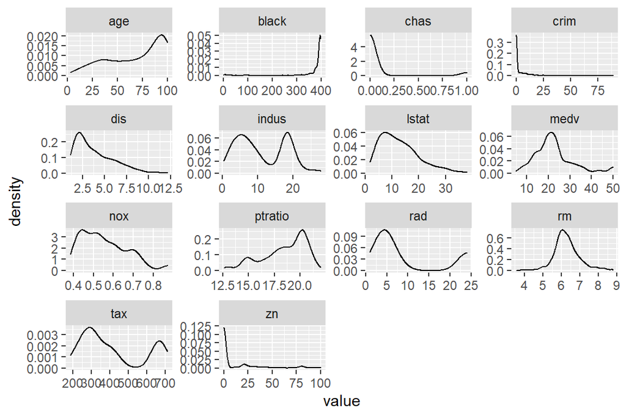

```r
# draw a bar plot of each variable

# we require dplyr, tidyr and ggplot for the below code chunk compiling the kernely densities
library(dplyr)
library(tidyr)
library(ggplot2)

gather(Boston) %>% ggplot(aes(value)) + geom_density() + facet_wrap("key", scales = "free")
```

We see that there is quite a lot of variability in terms of the suburbs in the Boston area. There are large differences in terms of the crime rate, the median value of the the houses, pollution, average count of rooms per apartment and even in the pupil to teacher ratio. By and large this looks quite promising in terms of ‘’profiling’’ the areas into distinct categories.

Yet we also observe that the variables are anything but normal, which is an issue for linear discriminant analysis.

Since we have a dataframe of mostly numeric and interval-valued variables, let us take a look at the pairwise Pearson correlation coefficients between the variables to see if some associations stand out.

```r
# We require the following libraries for the correlation plot
library(tidyr)
library(corrplot)
# calculate the correlation matrix and round it
cor_matrix <- Boston %>% cor() %>% round(digits=2)

# print the correlation matrix
cor_matrix
```

```
##          crim    zn indus  chas   nox    rm   age   dis   rad   tax ptratio
## crim     1.00 -0.20  0.41 -0.06  0.42 -0.22  0.35 -0.38  0.63  0.58    0.29
## zn      -0.20  1.00 -0.53 -0.04 -0.52  0.31 -0.57  0.66 -0.31 -0.31   -0.39
## indus    0.41 -0.53  1.00  0.06  0.76 -0.39  0.64 -0.71  0.60  0.72    0.38
## chas    -0.06 -0.04  0.06  1.00  0.09  0.09  0.09 -0.10 -0.01 -0.04   -0.12
## nox      0.42 -0.52  0.76  0.09  1.00 -0.30  0.73 -0.77  0.61  0.67    0.19
## rm      -0.22  0.31 -0.39  0.09 -0.30  1.00 -0.24  0.21 -0.21 -0.29   -0.36
## age      0.35 -0.57  0.64  0.09  0.73 -0.24  1.00 -0.75  0.46  0.51    0.26
## dis     -0.38  0.66 -0.71 -0.10 -0.77  0.21 -0.75  1.00 -0.49 -0.53   -0.23
## rad      0.63 -0.31  0.60 -0.01  0.61 -0.21  0.46 -0.49  1.00  0.91    0.46
## tax      0.58 -0.31  0.72 -0.04  0.67 -0.29  0.51 -0.53  0.91  1.00    0.46
## ptratio  0.29 -0.39  0.38 -0.12  0.19 -0.36  0.26 -0.23  0.46  0.46    1.00
## black   -0.39  0.18 -0.36  0.05 -0.38  0.13 -0.27  0.29 -0.44 -0.44   -0.18
## lstat    0.46 -0.41  0.60 -0.05  0.59 -0.61  0.60 -0.50  0.49  0.54    0.37
## medv    -0.39  0.36 -0.48  0.18 -0.43  0.70 -0.38  0.25 -0.38 -0.47   -0.51
##         black lstat  medv
## crim    -0.39  0.46 -0.39
## zn       0.18 -0.41  0.36
## indus   -0.36  0.60 -0.48
## chas     0.05 -0.05  0.18
## nox     -0.38  0.59 -0.43
## rm       0.13 -0.61  0.70
## age     -0.27  0.60 -0.38
## dis      0.29 -0.50  0.25
## rad     -0.44  0.49 -0.38
## tax     -0.44  0.54 -0.47
## ptratio -0.18  0.37 -0.51
## black    1.00 -0.37  0.33
## lstat   -0.37  1.00 -0.74
## medv     0.33 -0.74  1.00
```

We have quite high Pearson correlations between the variables. This seems in a sense intuitive, when looking at the variables measured, and their unidimensional distributions, which indicate that the suburbs in the Boston area are quite heterogeneous. High unidimensional variance makes room for meaningful correlation structures; the fact that one may posit that some values of features tend to go together, just by looking at what they measure (a simple example, say, pollution and industry), has one believe that such sructures will indeed emerge from our data.

From the perspective of urban studies, even if all of the suburbs of an area started out as relatively similar to each other, one would tend to get, through time, internally more and more homogeneous groups of suburbs, which, in turn, would tend to get less and less alike when looking at the differences between these groups having newly emerged. For what we often get is a mechanism of ‘’preferential attachment’‘, where alike attract alike, along a geographical accumulation of challenges, resulting in issues such as segregation, and polarization between the’‘good’’ and the ‘’bad’’ neighbourhoods.

To provide an illustrative if crass example: if one neighborhood had, initially, a somewhat higher proportion of rich citizens to the rest, as a novel rich citizen contemplates moving from one suburb to another, or entirely from outside of the area and into it, he is, ceteris paribus, more likely to choose the area with a relatively high proportion of the rich. Moreover, the probability of choosing a given suburb might be directly proportional with the proportion of the wealthy already living in it. Then, as the process iterates, the proportion of the wealthy within that suburb grows ever larger, and along it increases also the probability of the wealthy moving in. This increases demand, and at some point the prizes of the suburb would climb to a level such that any further wealthy individual contemplating moving in would start to favor an area with the second highest proportion of the wealthy instead, or perhaps prefer to move to a suburb adjacent to the wealthiest neighborhood. Thus, even if one had, at first, in absolute standards, relatively homogeneous suburbs by wealth, one would tend to get an increased variance of wealth across the suburbs through time, with clear clusters being formed by differences in wealth. Of course, wealth would then bring along with it other distinctive features to the neighborhood that are associated with wealth, resulting in a formation of multivariate clusters (say, some suburbs having high average income as well as low crime rates).

With that intro to the hypothesized dynamics to cluster formation in urban areas, let us look at a plot of the correlation matrix to see what pairwise profiles of suburbs in Boston pop out.

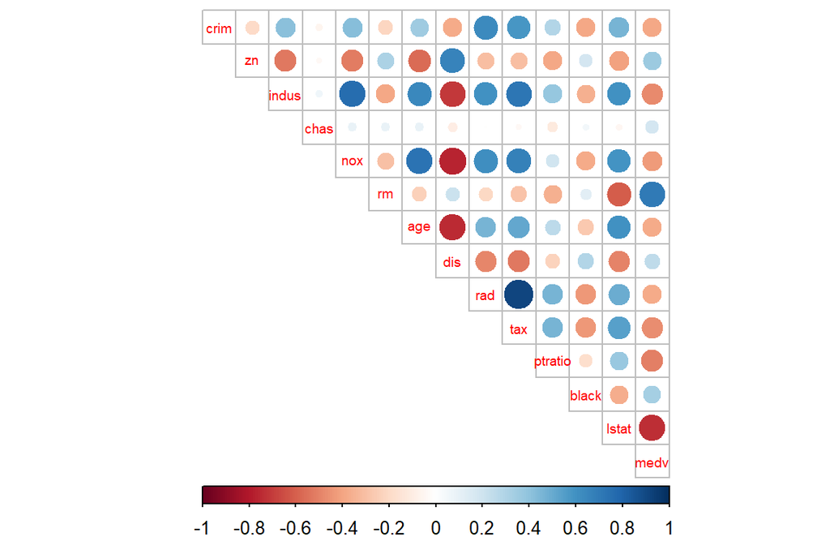

```r
# visualize the correlation matrix
corrplot(cor_matrix, method="circle", type="upper", cl.pos="b", tl.pos="d", tl.cex=0.6)
```

When looking at individual variables, we can see that ‘’indus’’ and ‘’nox’’ have particularly high absolute pairwise correlations with the rest of the variables, which is quite interesting, given the range of the content of the variables from educational issues to prizing and crime. ‘’Indus’’ and ‘’nox’’ also have a very high correlation between each other, which is unsurprising, since the former measures the amount of non-retail commercial ares (which I guess is mostly industry) and ‘’nox’’ pollution. We see that industrial areas are ones that are close to the highways, have high property tax rate and relatively high crime rates. The ‘’polluted’’ areas have similar profiles, since the correlation between industry and pollution is so high.

If we restrict our attention to the first row of the correlation matrix, since we are soon to delve more closely into the issue of crime, we may observe that the highest absolute correlations are with highway accessibility, industry, air pollution, proportion of ‘’low status’’ population and property tax rate. All these have a Pearson sample correlation coefficient of above 0.4.

## Standardization and other preprocessing prior to analysis

Let us standardize the data: subtract the variable value by the mean of the variable and divide by its standard deviation. This might be useful given the different variances and ranges to the variables. *For if we did not scale*, large numerical distances would be found on the basis of those variables with high variance and range, even though such induced differences might not be large in the conceptual sense. On the contrary, when we are comparing observations on the standardized scale, we are interpreting ‘’large’’ in the appropriate context of the variable that accounts for the fact that different variables are measured on very different scales (even if they were all interval-scaled). A seemingly large difference of, say, 4, between observations in the original scale of a variable with a variance of 25, *ought by default not be considered as large as* a difference of 2 in terms of a variable with variance of 1 (this being reflected in the standardized scale, where the former amounts to a difference of 0.8 units of sd, and the the latter 2 units of sd). In short, without scaling, identified differences in terms of distances would tend to be driven by the absolute differences in the observations on those variables with high spread, even if such differences were not conceptually large or even noteworthy.

```r
# center and standardize variables
boston_scaled <- Boston %>% scale() %>% as.data.frame()

# summaries of the scaled variables
summary(boston_scaled)
```

```
##       crim                 zn               indus              chas
##  Min.   :-0.419367   Min.   :-0.48724   Min.   :-1.5563   Min.   :-0.2723
##  1st Qu.:-0.410563   1st Qu.:-0.48724   1st Qu.:-0.8668   1st Qu.:-0.2723
##  Median :-0.390280   Median :-0.48724   Median :-0.2109   Median :-0.2723
##  Mean   : 0.000000   Mean   : 0.00000   Mean   : 0.0000   Mean   : 0.0000
##  3rd Qu.: 0.007389   3rd Qu.: 0.04872   3rd Qu.: 1.0150   3rd Qu.:-0.2723
##  Max.   : 9.924110   Max.   : 3.80047   Max.   : 2.4202   Max.   : 3.6648
##       nox                rm               age               dis
##  Min.   :-1.4644   Min.   :-3.8764   Min.   :-2.3331   Min.   :-1.2658
##  1st Qu.:-0.9121   1st Qu.:-0.5681   1st Qu.:-0.8366   1st Qu.:-0.8049
##  Median :-0.1441   Median :-0.1084   Median : 0.3171   Median :-0.2790
##  Mean   : 0.0000   Mean   : 0.0000   Mean   : 0.0000   Mean   : 0.0000
##  3rd Qu.: 0.5981   3rd Qu.: 0.4823   3rd Qu.: 0.9059   3rd Qu.: 0.6617
##  Max.   : 2.7296   Max.   : 3.5515   Max.   : 1.1164   Max.   : 3.9566
##       rad               tax             ptratio            black
##  Min.   :-0.9819   Min.   :-1.3127   Min.   :-2.7047   Min.   :-3.9033
##  1st Qu.:-0.6373   1st Qu.:-0.7668   1st Qu.:-0.4876   1st Qu.: 0.2049
##  Median :-0.5225   Median :-0.4642   Median : 0.2746   Median : 0.3808
##  Mean   : 0.0000   Mean   : 0.0000   Mean   : 0.0000   Mean   : 0.0000
##  3rd Qu.: 1.6596   3rd Qu.: 1.5294   3rd Qu.: 0.8058   3rd Qu.: 0.4332
##  Max.   : 1.6596   Max.   : 1.7964   Max.   : 1.6372   Max.   : 0.4406
##      lstat              medv
##  Min.   :-1.5296   Min.   :-1.9063
##  1st Qu.:-0.7986   1st Qu.:-0.5989
##  Median :-0.1811   Median :-0.1449
##  Mean   : 0.0000   Mean   : 0.0000
##  3rd Qu.: 0.6024   3rd Qu.: 0.2683
##  Max.   : 3.5453   Max.   : 2.9865
```

Each of our variables now have a mean of zero and a standard deviation of 1. It is important to emphasize that the shapes to the kernels remain as before: clearly nonnormal.

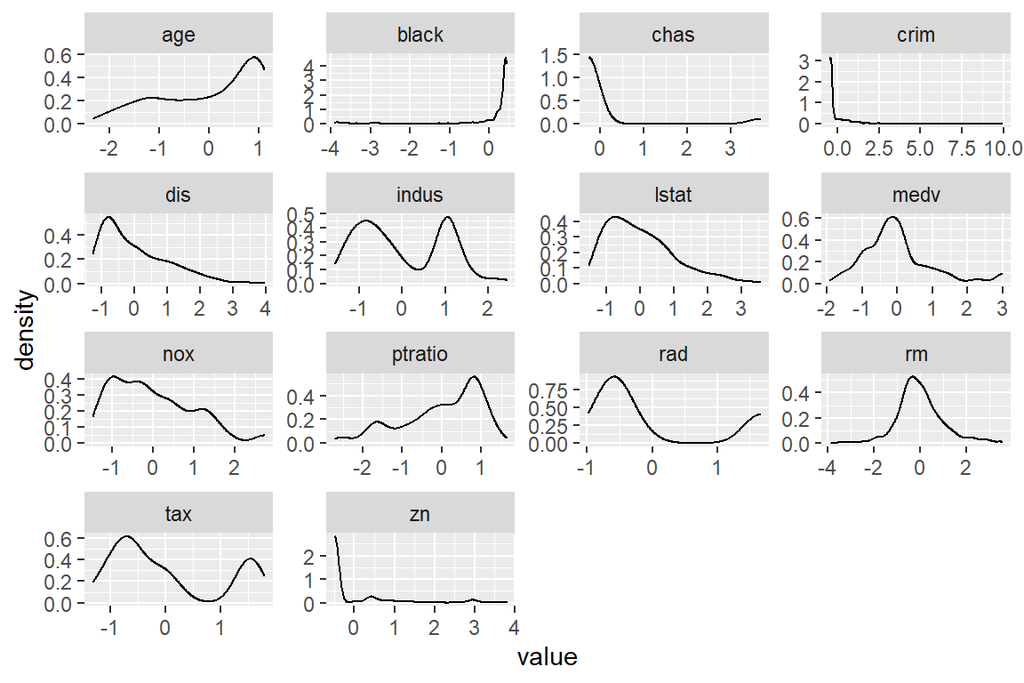

```r
# draw a bar plot of each variable
gather(boston_scaled) %>% ggplot(aes(value)) + geom_density() + facet_wrap("key", scales = "free")
```

We next turn the crime rate into a factor by utilizing the quartiles as the cut-off points for each level of the factor. We also remove the old crime variable and insert the novel factor into our dataframe.

```r
# create a quantile vector of crim and print it
bins <- quantile(boston_scaled$crim)

# create a categorical variable 'crime'
crime <- cut(boston_scaled$crim, breaks = bins, include.lowest = TRUE, labels=c("low", "med_low", "med_high", "high"))

# remove original crim from the dataset
boston_scaled <- dplyr::select(boston_scaled, -crim)

# add the new categorical value to scaled data
boston_scaled <- data.frame(boston_scaled, crime)

# look at the table of the new factor crime
table(crime)
```

```
## crime
##      low  med_low med_high     high
##      127      126      126      127
```

Having used quartiles as the cut-off points, we have groups of the same size, which will be handy for linear discriminant analysis. The names for the levels are in an ascending order of the crime rate.

We then divide our dataframe into a training and a test dataset, so that a random 80% of the rows go into the first and the rest to the second dataset.

```r
# number of rows in the Boston dataset
n <- nrow(boston_scaled)

set.seed(13)

# choose randomly 80% of the rows
ind <- sample(n,  size = n * 0.8)

# create train set
train <- boston_scaled[ind,]

# create test set
test <- boston_scaled[-ind,]

# save the correct classes from test data
correct_classes <- test$crime

# remove the crime variable from test data
test <- dplyr::select(test, -crime)
```

## Identifying the level of the crime factor with linear discriminant analysis

*Even though our predictors are anything but normally distributed*, we next fit linear discrimant analysis to the dataset, using the crime factor variable as the predicted class and the rest of the dataset as predictors to the class. We then plot the clusters by the linear discriminants in order to see how well we are able to distinguish the clusters.

```r
set.seed(13)

# linear discriminant analysis
lda.fit <- lda(crime~., data = train)

# print the lda.fit object
lda.fit
```

```
## Call:
## lda(crime ~ ., data = train)
##
## Prior probabilities of groups:
##       low   med_low  med_high      high
## 0.2500000 0.2425743 0.2500000 0.2574257
##
## Group means:
##                  zn      indus        chas        nox          rm        age
## low       1.0387189 -0.9767339 -0.07742312 -0.9069312  0.42495894 -0.9610733
## med_low  -0.1505672 -0.2741192 -0.03128211 -0.5232661 -0.17044394 -0.2322348
## med_high -0.4099764  0.2163751  0.27340760  0.4081463  0.03035225  0.4361659
## high     -0.4872402  1.0170690 -0.04518867  1.0673319 -0.34504206  0.8466357
##                 dis        rad        tax    ptratio       black       lstat
## low       0.9716949 -0.6839520 -0.7187624 -0.4692634  0.37666578 -0.75944749
## med_low   0.2196880 -0.5541258 -0.4786835 -0.0275366  0.31157562 -0.08476445
## med_high -0.3804549 -0.4065006 -0.2926143 -0.2538600  0.05994208  0.03839268
## high     -0.8621139  1.6386213  1.5144083  0.7813507 -0.79744136  0.95896029
##                 medv
## low       0.49895878
## med_low  -0.02919621
## med_high  0.11065317
## high     -0.70581567
##
## Coefficients of linear discriminants:
##                 LD1         LD2          LD3
## zn       0.06730671  0.72287941 -0.677952513
## indus    0.01284008 -0.33836495  0.227548425
## chas    -0.08008875 -0.07027516  0.005438349
## nox      0.40439038 -0.42138772 -1.626337373
## rm      -0.10631135 -0.02058266 -0.172746305
## age      0.31076921 -0.47152796 -0.105698304
## dis     -0.04654913 -0.14471928 -0.333792125
## rad      3.15924739  0.84542009  0.093315372
## tax      0.02473731  0.08339073  0.382334733
## ptratio  0.10350540  0.08612476 -0.231180070
## black   -0.11571284 -0.01011184  0.099358292
## lstat    0.24418102 -0.12223021  0.211722225
## medv     0.22199933 -0.26865999 -0.367808096
##
## Proportion of trace:
##    LD1    LD2    LD3
## 0.9452 0.0434 0.0114
```

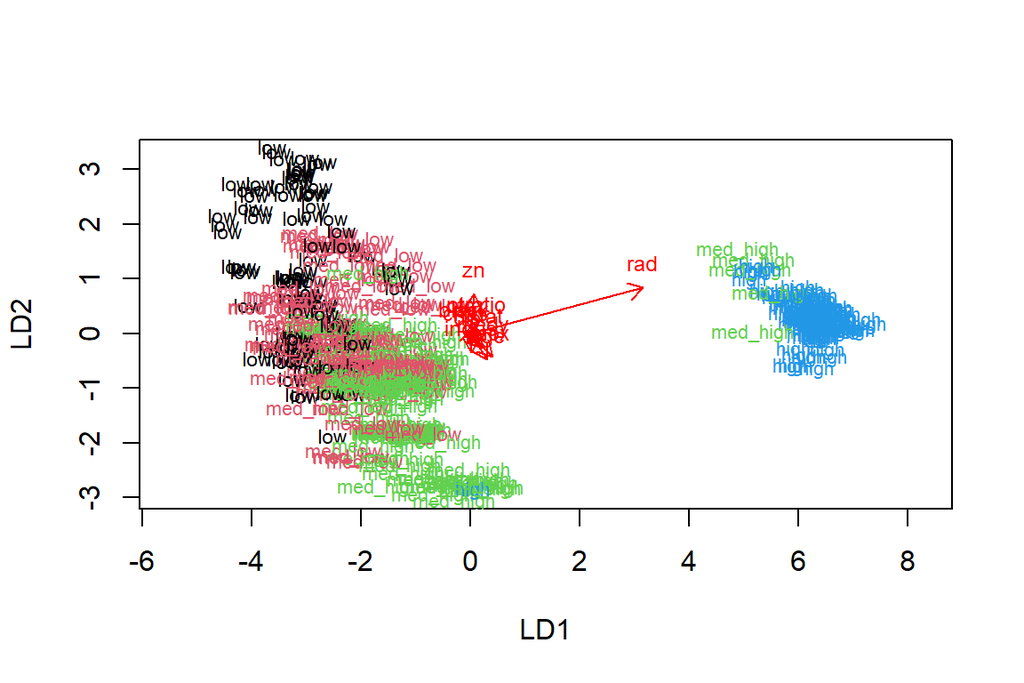

```r
# the function for lda biplot arrows
lda.arrows <- function(x, myscale = 1, arrow_heads = 0.1, color = "red", tex = 0.75, choices = c(1,2)){
  heads <- coef(x)
  graphics::arrows(x0 = 0, y0 = 0,
         x1 = myscale * heads[,choices[1]],
         y1 = myscale * heads[,choices[2]], col=color, length = arrow_heads)
  text(myscale * heads[,choices], labels = row.names(heads),
       cex = tex, col=color, pos=3)
}

# target classes as numeric
classes <- as.numeric(train$crime)

# plot the lda results (select both lines and execute them at the same time!)
plot(lda.fit, dimen = 2, col = classes, pch = classes)
lda.arrows(lda.fit, myscale = 1)
```

We may note from the output of our analysis that the high crime suburbs are those with good highway accessibility, high levels of industry, air pollution, proportion of ‘’low status’’ population and property tax rate. These suburbs also have, on average, higher pupil to teacher ratios (more pupils per teacher), shorter distance to employment centers and cheaper apartments.

## Predicting the level of the crime factor with linear discriminant analysis

So it would seem on the basis of the visual plot that our linear discriminant analysis holds promise in terms of predicting crime factor levels. We may evaluate the fit more closely by looking at how well our model predicts the classes of the test dataset on which it has not been fitted. Our test set has 102 observations.

```r
# predict classes with test data
lda.pred <- predict(lda.fit, newdata = test)

# cross tabulate the results
table(correct = correct_classes, predicted = lda.pred$class)
```

```
##           predicted
## correct    low med_low med_high high
##   low       10      12        4    0
##   med_low    9      16        3    0
##   med_high   2       7       15    1
##   high       0       0        0   23
```

We seem to have quite good classification performance: with the correct predictions found on the diagonal, we have a sum total of 64, which comes down to an accuracy of $64/102\sim=0.628$.With a balanced baseline, so that all classes are of the same size, without our predictors and our model, we would have an accuracy of $0.25$. Compared to that our model classifies relatively well.

We get the ‘’high’’ class correctly predicted especially well, with all observations of the test set belonging to that category being classified correctly. It proves more difficult for us to make the distinctions for the two low-groups than the two high groups (as we detected already from our visual): when the correct class is low, we get our prediction correct with proportion $10/26=0.385$, with $12$ observations predicted to the med_low category; when the correct class is med_low, we get our prediction correct $16/28=0.571$ of the time, with 12 incorrectly predicted in the low or the med_high category. Finally, when the correct class is med_high, we get $15/25=0.6$ correct. Note that no matter what the correct class is, even with the low crime rate classes we have difficulties in distinguishing from each other, we get the class predicted right with a considerably higher proportion than what would be expected from mere guessing alone (0.25). As the level of the crime factor increases, we get better at our predictions.

Nonetheless, we would likely be better at classifying observations into fewer classes: or, to put it differently, it seems there is relatively little in our features that would allow us to distinguish between the suburbs with low and med_low crime rates, whereas we are better at distinguishing between the two low categories and the two high categories. We are especially apt at identifying the high crime rate suburbs. These suburbs are apparently characterized by features that they very much share with each other but which the other classes of suburbs do not have (some characteristics of which we have already enlisted in the above).

## K-means clustering

```r
# Rescale Boston dataset and retain its type as a data.frame object
Boston_scaled2<-as.data.frame(scale(Boston))

# Euclidean distance matrix
dist_eu <- dist(Boston_scaled2)

# look at the summary of the distances
summary(dist_eu)
```

```
##    Min. 1st Qu.  Median    Mean 3rd Qu.    Max.
##  0.1343  3.4625  4.8241  4.9111  6.1863 14.3970
```

```r
# manhattan distance matrix
dist_man <- dist(Boston, method="manhattan")

# look at the summary of the distances
summary(dist_man)
```

```
##     Min.  1st Qu.   Median     Mean  3rd Qu.     Max.
##    2.016  149.145  279.505  342.899  509.707 1198.265
```

We then run the K-means clustering algorithm, first with four clusters. We print the clusters as functions of the predictors. Since there are 14 predictors, we split the visuals into three partitions of the variables.

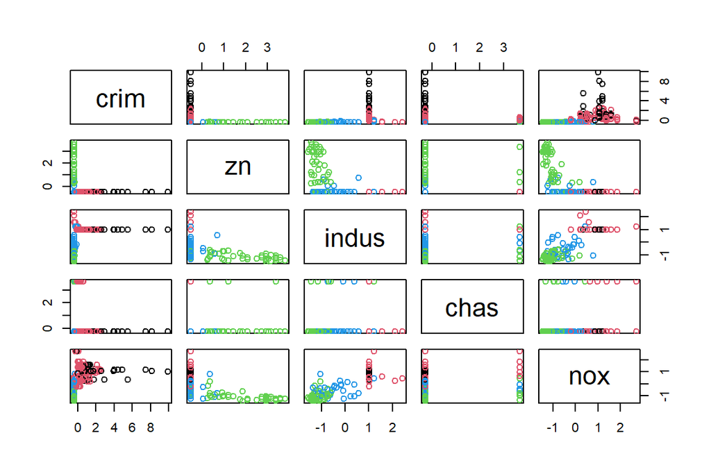

```r
# Set seed for reproducibility
set.seed(123)

# k-means clustering
km <- kmeans(Boston_scaled2, centers = 4)

# plot the Boston dataset with clusters, variables 1 to 5
pairs(Boston_scaled2[1:5], col = km$cluster)
```

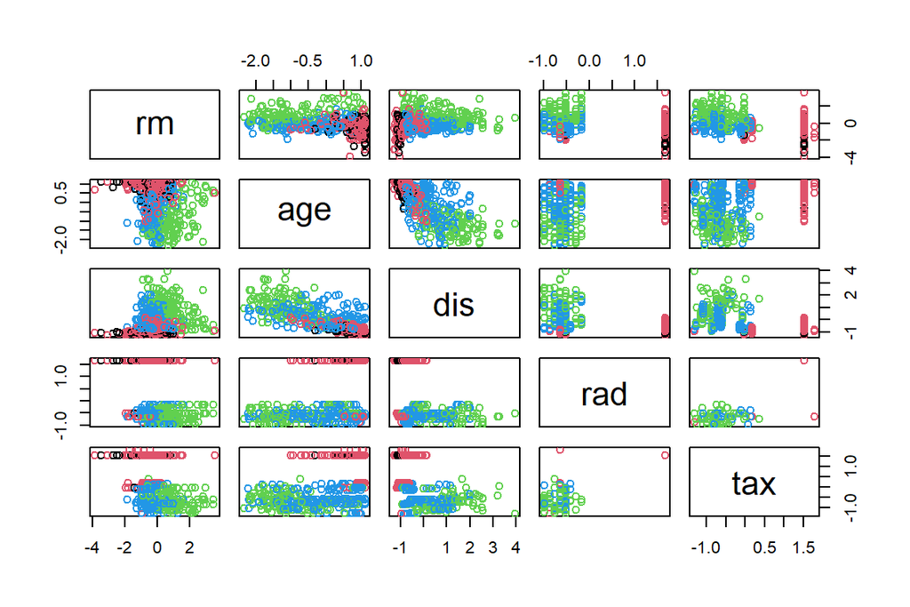

```r
# plot the Boston dataset with clusters, variables 6 to 10
pairs(Boston_scaled2[6:10], col = km$cluster)
```

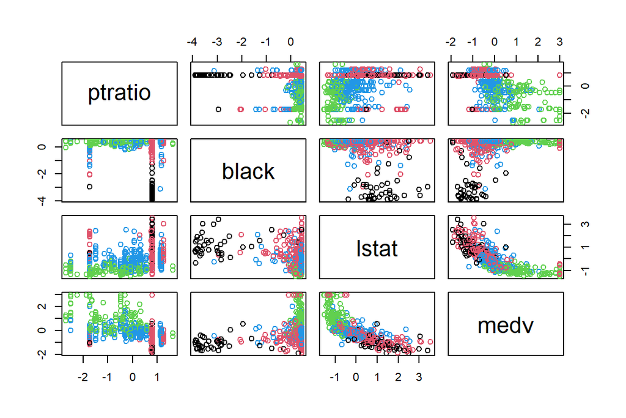

```r
# plot the Boston dataset with clusters, variables 10 to 15
pairs(Boston_scaled2[11:14], col = km$cluster)
```

We note from the two-dimensional visuals of the clusters that while we have an ability to distinguish the clusters, these tend to overlap, with the possible exception the cluster colored in black. This cluster can be distinguished from the others pretty well in terms of a low value measured on the variable ‘’black’’.